# Portrait des ménages et de leur logement

# 4.1.1.6 Typologie selon le mode d’occupation

*Source: Statistique Canada, Recensement de la population de 2021, analyse et traitement des données par Curbcut*

Le graphique suivant confirme des tendances bien établies en matière de logement : un tiers des propriétaires lavallois réside dans des maisons individuelles non attenantes (32,0 %), et ils sont également plus nombreux, en proportion, à habiter dans des maisons en rangée (1,9 %) ou jumelées (6,4 %) comparativement aux locataires, dont seulement 0,6 % vivent dans des maisons en rangée et 0,8 % dans des maisons jumelées. Un tiers des locataires vit dans des appartements dans des immeubles de moins de cinq étages (33,2 %), et globalement, la quasi-totalité des locataires habitent dans un appartement (de plain-pied dans un duplex à immeubles de cinq étages ou plus).

Pour approfondir l’analyse de la typologie des logements selon le mode d’occupation et l’âge du principal soutien du ménage, il serait nécessaire d’accéder à des données plus détaillées du recensement canadien. Ces données permettraient de mieux comprendre les choix de logement selon les tranches d’âge, en particulier pour les 65 ans et plus.

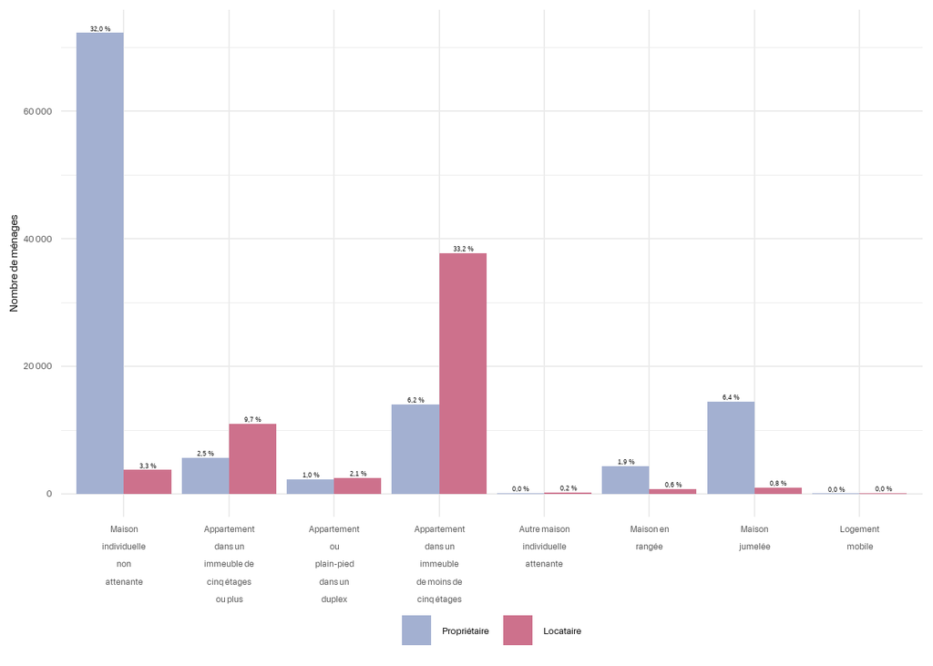

Répartition des ménages selon le type de logement et le mode d’occupation

# 4.1.2.1 Projection des ménages

_Source: Statistique Canada, Recensement de la population de 2011, 2016 et 2021, analyse et traitement des données par Curbcut ; Projections de ménages - Régions administratives et régions métropolitaines (RMR). (2024). Institut de la statistique du Québec. Récupéré au https://statistique.quebec.ca/fr/document/projections-de-menages-regions-administratives-et-regions-metropolitaines-rmr ; Projections de ménages - Régions administratives et régions métropolitaines (RMR). (2024). Institut de la statistique du Québec. Récupéré au https://statistique.quebec.ca/fr/document/projections-de-menages-regions-administratives-et-regions-metropolitaines-rmr_

De 2011 à 2021, la ville de Laval a connu une croissance de 10,7 % ménages, passant de 154 455 ménages en 2011 à 170 975 en 2021. Au cours des 20 prochaines années suivant le dernier recensement, soit d’ici 2041, la croissance du nombre de ménages devrait ralentir, avec une augmentation de seulement 13,6 %, pour atteindre 194 234 ménages en 2041. La ville devrait compter environ 184 200 ménages en 2029, 188 300 en 2033, 191 600 en 2037, 196 300 en 2046 et 197 600 en 2051.

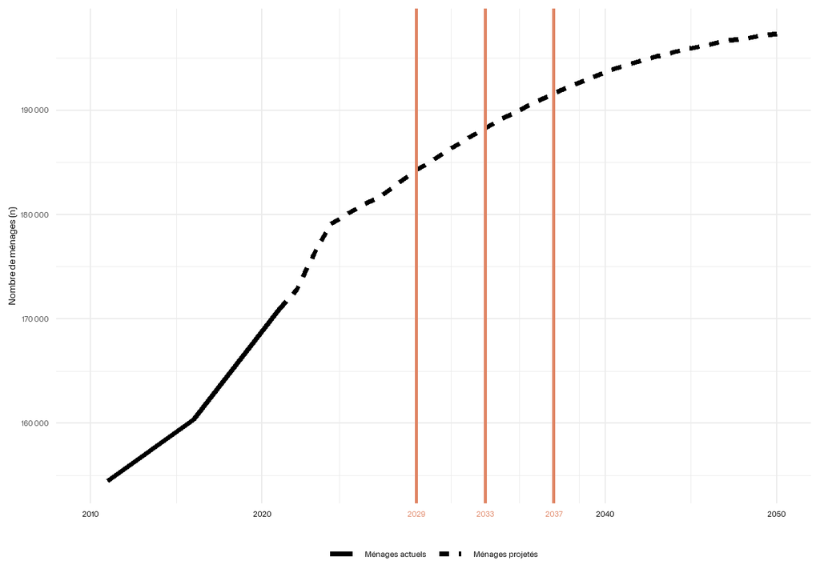

Projection des ménages de 2021 à 2051.

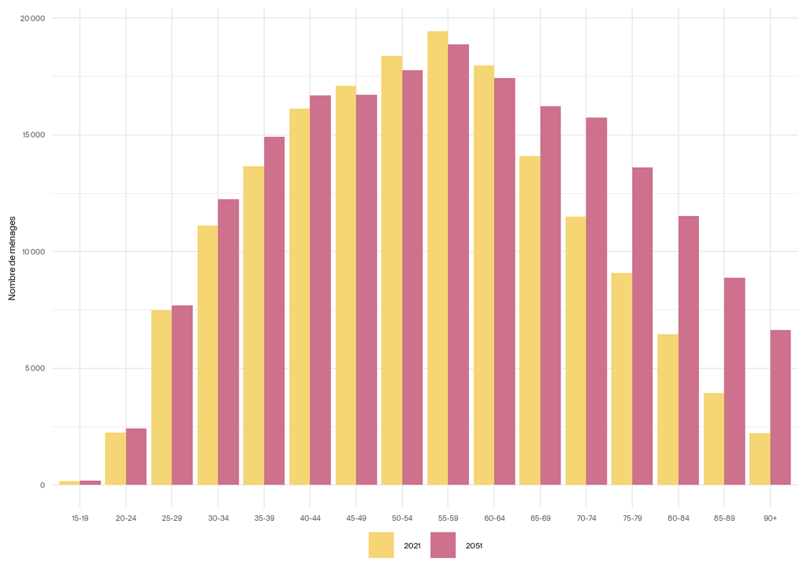

Projections du nombre de ménages par groupe d’âge de 2021 à 2051

# 4.1.2.2 Croissance prévue des ménages

# 4.1.2.3.1 Projections de la population selon le groupe d’âge

_Source: Projections de population - MRC. (2024). Institut de la statistique du Québec. Récupéré au https://statistique.quebec.ca/fr/document/projections-de-population-mrc-municipalites-regionales-de-comte_

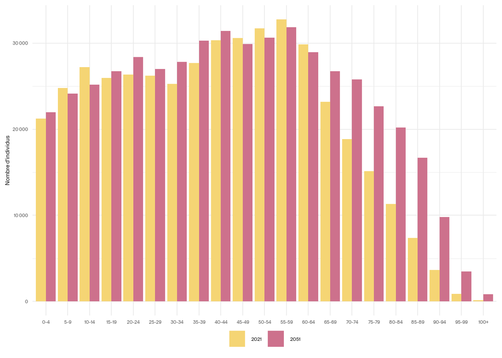

Projections du nombre d’individus par groupe d’âge de 2021 à 2051

# 4.1.2.3.2 Composantes de la croissance démographique annuelle

_Source: Composantes démographiques projetées, scénario Référence A2022, MRC du Québec, 2021-2041. (2022). Institut de la statistique du Québec. Récupéré au https://statistique.quebec.ca/fr/document/projections-de-population-mrc-municipalites-regionales-de-comte_

Le solde migratoire international devient la principale source de croissance démographique, jouant un rôle de plus en plus important pour compenser la baisse de la population due à l’accroissement naturel négatif. L’immigration internationale semble donc cruciale pour maintenir la croissance démographique de Laval à long terme.

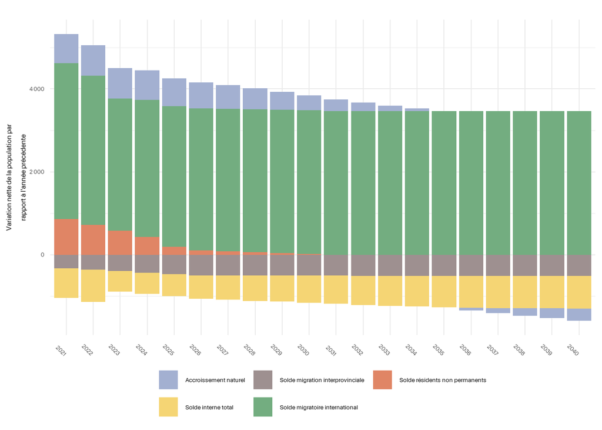

Composantes de la croissance démographique annuelle projetée à Laval de 2021 à 2040